# 911 Police Service Calls in Baltimore City for 2017

Kristen Corlay Sanmiguel

1/15/2021

# Introduction

My data is the 911 Police Calls for Service in Baltimore City. I decided to work with this data because I wanted to be more familiar with working with local government data since I’m going to be starting a research project with a Baltimore City data set.

The data used in this project is originally from Baltimore Open Data, published by the Baltimore City government in https://data.baltimorecity.gov/

I downloaded it from Data World because I was having some issues downloading from the original website. Data World provided this download link and I saved the csv file to my project folder: https://query.data.world/s/7bahpmnbgy44awqf4xima4iz53agzq

The data set has 7 variables, including the call date time, priority, district, description, call number, incident location, and call location. For this project, II will focus on three main variables: call date time, priority, and district. From my data I want to explore the differences of total number of calls per district, as well as the call priority for each one of them. I want to know if all districts follow the same monthly trends for increase or decrease in calls. With this in mind, I made the following questions:

- What were the months with the most amount of calls per district?
- What was the distribution for call priority per district?

I decided to uniquely analyze 2017 data because I wanted to use the most recent data possible. The 2018 and 2019 sets had missing months and were not as complete as the 2017 data, so that was the most recent year I could use.

```r
library(readr)
library(stringr)
library(dplyr)
library(lubridate)
library(tidyverse)
library(magrittr)
library(gt)
library(pander)
library(rmarkdown)
library(ggplot2)
library(rmdformats)
```

# Data Cleaning Process

In this section I will walk you through my steps for cleaning my data.

## Formatting Initial Data Frame

Loading my data

```r
calls_service <- read_csv("calls_service.csv")
View(calls_service)
calls.frame <- as.data.frame(calls_service) #making data frame
class(calls.frame)
```

Exploring my data

```r
sum(is.na(calls.frame))
```

```
## [1] 234229
```

```r
nrow(calls.frame)
```

```
## [1] 3167006
```

```r
typeof(calls.frame)
```

```
## [1] "list"
```

```r
length(calls.frame$district)
```

```
## [1] 3167006
```

```r
unique(calls.frame$district)
```

```
##  [1] "NE"   "NW"   "CD"   "SD"   "ED"   "SW"   "WD"   "TRU"  "CW"   "ND"
## [11] "SE"   "SS"   "EVT2" "INFO" "EVT1" "EVT3" "FIR1" "HP"
```

Formatting the dates

```r
#putting date and time in different columns, making them in a new data frame
date.calls <- as.data.frame(str_split(calls.frame$callDateTime," ", simplify = TRUE))
colnames(date.calls)[1] <- "wrong.date" #changing col name

#changing to date notation for R, putting it in new column
date.calls$date <- as.Date(date.calls$wrong.date, format = "%m/%d/%Y")

#combining the column of this data set into the one i'm working with
calls.table <- as.data.frame(cbind(calls.frame, date.calls$date))

#renaming the column of the date
colnames(calls.table) [9] <- "date"

date.calls$full.time <- paste0(date.calls$V2, " ", date.calls$V3)

#changing to time format
date.calls$new.time <- parse_time(date.calls$full.time, "%I:%M:%S %p")

#now adding new.time as a column to calls.table
calls.table <- as.data.frame(cbind(calls.frame, date.calls$date, date.calls$new.time))

#changing column names to date and time
colnames(calls.table) [9] <-"call.date"
colnames(calls.table) [10] <- "call.time"

#Only putting 2017 data
calls.2017 <- dplyr::filter(calls.table, call.date >= as.Date("2017-01-01"),
                            call.date <= as.Date("2017-12-31"))
```

Sample of 10 rows

```r
head(calls.2017, 10)
```

```
##    recordId           callDateTime      priority district    description
## 1   2166363 01/18/2017 11:08:00 AM        Medium       NE     DISORDERLY
## 2   2167138 01/18/2017 04:20:00 PM           Low       CD  DESTRUCT PROP
## 3   2166404 01/18/2017 11:27:00 AM           Low       NW FALSE PRETENSE
## 4   2167498 01/18/2017 06:19:00 PM        Medium       SW     DISORDERLY
## 5   2167045 01/18/2017 03:50:00 PM           Low       NE  DESTRUCT PROP
## 6   2166107 01/18/2017 09:08:00 AM        Medium       CD  911/NO  VOICE
## 7   2167515 01/18/2017 06:26:00 PM           Low       NE        LARCENY
## 8   2166381 01/18/2017 11:14:00 AM        Medium       NW  911/NO  VOICE
## 9   2166728 01/18/2017 01:43:00 PM Non-Emergency       SE SUPV COMPLAINT
## 10  2166243 01/18/2017 10:14:00 AM        Medium       NW MISSING PERSON
##    callNumber     incidentLocation
## 1  P170180959      6700 HARFORD RD
## 2  P170181854        1200 EUTAW PL
## 3  P170181008       5100 WABASH AV
```

[output cut: 29 more lines]

## Organizing Call Priority

```r
#New data frame since I will be deleting variables
types.calls <- as.data.frame(calls.2017)
```

Exploring this data

```r
#Finding missing values in my priority and district column
sum(is.na(types.calls$priority))
```

```
## [1] 0
```

```r
sum(is.na(types.calls$district))
```

```
## [1] 0
```

```r
#Finding types of priorities
unique(types.calls$priority)
```

```
## [1] "Medium"         "Low"            "Non-Emergency"  "High"
## [5] "Emergency"      "Out of Service"
```

```r
#I want to know the frequency of each priority type
sum(types.calls$priority == "Out of Service")
```

```
## [1] 167
```

```r
sum(types.calls$priority == "Non-Emergency")
```

```
## [1] 101611
```

```r
sum(types.calls$priority == "Emergency")
```

```
## [1] 334
```

```r
sum(types.calls$priority == "Medium")
```

```
## [1] 488464
```

```r
sum(types.calls$priority == "High")
```

```
## [1] 168745
```

```r
sum(types.calls$priority == "Low")
```

```
## [1] 210374
```

Making a binary flag to exclude out of service calls since they were not completed.

```r
types.calls$out.service <- as.factor(ifelse(types.calls$priority == "Out of Service", "1", "0"))
sum(types.calls$out.service == 1) #verifying binary flag matches the priority column

#deleting rows with out of service
priority.calls <- subset(types.calls, types.calls$priority != "Out of Service")
sum(priority.calls$priority == "Out of Service") #verifying my work
```

Sorting this data set

```r
#now time to sort everything using dplyr
new.priority <- priority.calls %>%
  arrange(district) %>% #arranging by neighborhood name
  group_by(district, priority) %>% #grouping by neighborhood and priority
  summarize(prioritycounts = n()) #make column that counts priority per neighborhood

#making priority a variable
clean.priority <- new.priority %>%
  pivot_wider(names_from = priority, values_from = prioritycounts)
```

Since an NA means there were no calls, I changed it to 0

```r
clean.priority[is.na(clean.priority)] <- 0
colnames(clean.priority) [1] <- "District" #Changed column name for practicality
```

Finishing touches

```r
#Making a final column to sum the amount of calls
clean.priority$Total <- rowSums(clean.priority[2:6])
```

Clean data set for call priority

```r
final.priority
```

```
## # A tibble: 9 x 7
## # Groups:   District [9]
##   District Emergency  High   Low Medium `Non-Emergency`  Total
##   <chr>        <int> <int> <int>  <int>           <int>  <dbl>
## 1 CD              47 16055 27329  58269            9329 111029
## 2 ED              35 16676 19551  46226            8104  90592
## 3 ND              24 16546 21442  41858           10208  90078
## 4 NE              33 25028 31285  66078           14733 137157
## 5 NW              42 16396 21440  56554            8535 102967
## 6 SD              46 19815 23395  54096           11840 109192
## 7 SE              35 21270 24158  48899           15189 109551
## 8 SW              19 19152 23636  56874           11665 111346
## 9 WD              51 17507 16833  46269            9245  89905
```

## Organizing Call Months

```r
#copying my 2017 data frame to work on a new data frame for this question
months.calls <- as.data.frame(calls.2017)
```

```r
#finding NA in dates
sum(is.na(months.calls$date))
```

```
## [1] 0
```

Subset by month, to prevent redundancy I will only put January as an example. I repeated the same process for all months

```r
january.calls <- dplyr::filter(months.calls, call.date >= as.Date("2017-01-01"),
                               call.date <= as.Date("2017-01-31"))
```

Then I arranged by district and call priority

```r
jan.new <- january.calls %>%
  arrange(district) %>%
  group_by(district, priority) %>% #grouping by neighborhood and priority
  summarize(prioritycounts = n())

#make priority a variable
jan.clean <- jan.new %>%
  pivot_wider(names_from = priority, values_from = prioritycounts)
jan.clean[is.na(jan.clean)] <- 0 #make NA values 0

#I will delete the out of service calls since those were not completed
jan.clean[7] <- NULL
jan.clean$jan.total <- rowSums(jan.clean[2:6])
```

Clean January data frame

```r
jan.clean
```

```
## # A tibble: 12 x 7
## # Groups:   district [12]
##    district Emergency  High   Low Medium `Non-Emergency` jan.total
##    <chr>        <int> <int> <int>  <int>           <int>     <dbl>
##  1 CD               5  1573  2307   4524             807      9216
##  2 CW               0    21    54   1283              32      1390
##  3 ED               3  1387  1744   4091             692      7917
##  4 ND               3  1287  1897   3526             779      7492
##  5 NE               0  2163  2655   5607            1140     11565
##  6 NW               3  1316  1765   4483             688      8255
##  7 SD               6  1787  1884   4132            1008      8817
##  8 SE               4  2245  2048   3653            1135      9085
##  9 SS               0    18     7     11             162       198
## 10 SW               1  1717  2007   4565            1001      9291
## 11 TRU              0     1   196      5               7       209
## 12 WD               0  1867  1464   3977             850      8158
```

Combining the monthly call totals per district

```r
#Combining month total calls ####
total.calls <- cbind(jan.clean$district, jan.clean$jan.total, feb.clean$feb.total,
                     mar.clean$mar.total, apr.clean$apr.total,
                     may.clean$may.total, june.clean$june.total,
                     july.clean$july.total, aug.clean$aug.total,
                     sept.clean$sept.total, oct.clean$oct.total,
                     nov.clean$nov.total, dec.clean$dec.total)
total.calls <- as.data.frame(total.calls)
#I verified this before cbinding by printing the row names of the districts
#and seing they all had the same order

#Changing column names
colnames(total.calls) <- c("District", "January", "February",
                           "March", "April", "May", "June",
                           "July", "August", "September", "October",
                           "November", "December")

#Making the columns with numbers integer
total.calls[2:13] <- lapply(total.calls[2:13], as.integer)

lapply(total.calls, typeof) #revising my work

#Making a final column with total amount of calls
total.calls$Year <- rowSums(total.calls[2:13])
total.calls$District
```

Final monthly calls

```r
final.total.calls
```

```
##    District January February March April   May  June  July August September
## 1        CD    9216     8207  9398  9563 10078  9722  9987  10147      9279
## 3        ED    7917     7296  7585  8244  8231  8256  8080   7585      7253
## 4        ND    7492     6823  7062  7498  8031  8309     1   7975         1
## 5        NE   11565    11041 11428 12383 12593 12243  7907  10996      7473
## 6        NW    8255     7660  8214  8707  9182  9530 12395   8922     10910
## 7        SD    8817     8065  8420  9955 10216  9892  9188   9795      8223
## 8        SE    9085     8001  8440  9020  9360  9581  9865   9994      9347
## 10       SW    9291     8476  9043 10158 10208 10432   241   9974       258
## 12       WD    8158     6979  7996  7696  8229  8098    40   7539        43
##    October November December   Year
## 1     9725     8026     7681 111029
## 3     7154     6729     6262  90592
## 4     7761       26        2  60981
## 5    11533     6890     6857 122909
## 6     8656     9951    10119 112501
## 7     9321     8405     8025 108322
## 8     9783     7799     7700 107975
## 10    8964      234      233  77512
## 12    7171       14       16  61979
```

This is the end of my data processing portion, where I cleaned a data set to produce two data frames with the variables I needed to answer my question. I only included the calls made to the 9 police districts in Baltimore City since they were the most relevant to my analysis.

# Tables

In this section I will show the reader how I made my tables.I first changed the names of the districts from their abbreviation to their full name to make my table more readable. I also made new data frames for each table to prevent writing over my clean final data frame to prevent overwrites.

## Call Priority Table

```r
table.priority %>%
  gt() %>%
  tab_header(
    title = "911 Police Service Call Priority in Baltimore City for 2017",
    subtitle = "Number of Calls by District") %>%
  tab_spanner(
    label = "Call Priority",
    columns = vars(Emergency, High, Low, Medium, Non.Emergency)
  )
```

911 Police Service Call Priority in Baltimore City for 2017

Number of Calls by District

[output not shown]

## Monthly Calls Table

```r
table.months %>%
  gt() %>%
  tab_header(
    title = "Monthly 911 Police Service Calls in Baltimore City",
    subtitle = "Number of Calls by District") %>%
  tab_spanner(
    label = "Month",
    columns = vars(January, February, March, April, May, June, July, August,
                   September, October, November, December))
```

Monthly 911 Police Service Calls in Baltimore City

Number of Calls by District

[output not shown]

# Graphs

In this section I will include my code to make my graphs and the final product. I also renamed the abbreviation of the districts to their full name.

To make this graph, I had to make months an integer to plot on the x axis. Additionally, I had to change months from being a variable per month, to a single month variable with all of them. This would allow me to plot them.

```r
#New Data Frame for graph
grouped.month <- fix.months.calls %>%
  dplyr::select(district, month) %>%
  dplyr::group_by(district, month) %>%
  dplyr::summarise(count = n())

#Making Month an integer
grouped.month$month <- as.integer(grouped.month$month)
names(grouped.month) [1] <- "District"
```

## 2017 Month Calls Graph

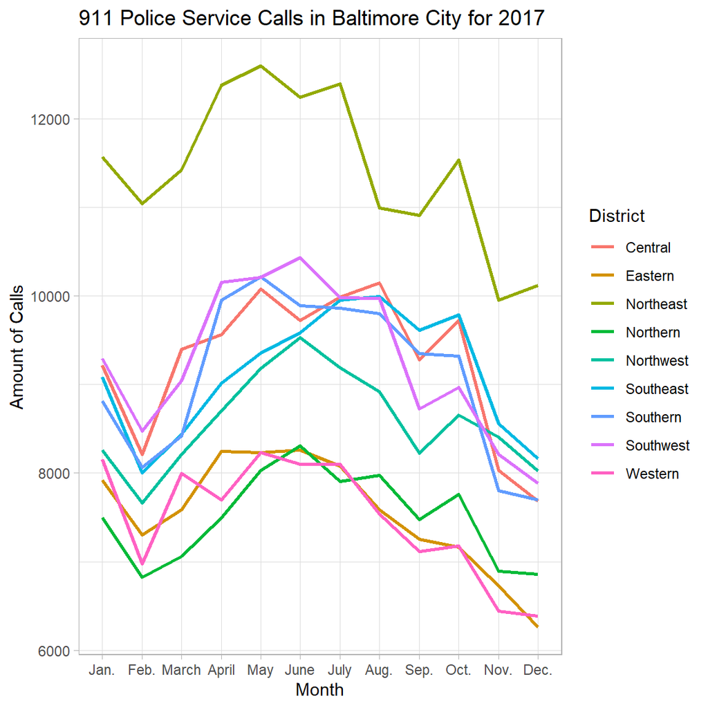

```r
ggplot(data = grouped.month,
       aes(x = month, y = count,
           color = District)) +
  scale_x_discrete(name = "Month",
                   limits = c("Jan.", "Feb.", "March", "April", "May", "June",
                              "July", "Aug.", "Sep.",
                              "Oct.", "Nov.", "Dec.")) +
  geom_line(size = 1) +
  xlab("Month") +
  ylab("Amount of Calls") +
  ggtitle("911 Police Service Calls in Baltimore City for 2017") +
  theme_light()
```

## 2017 Calls by District Graph

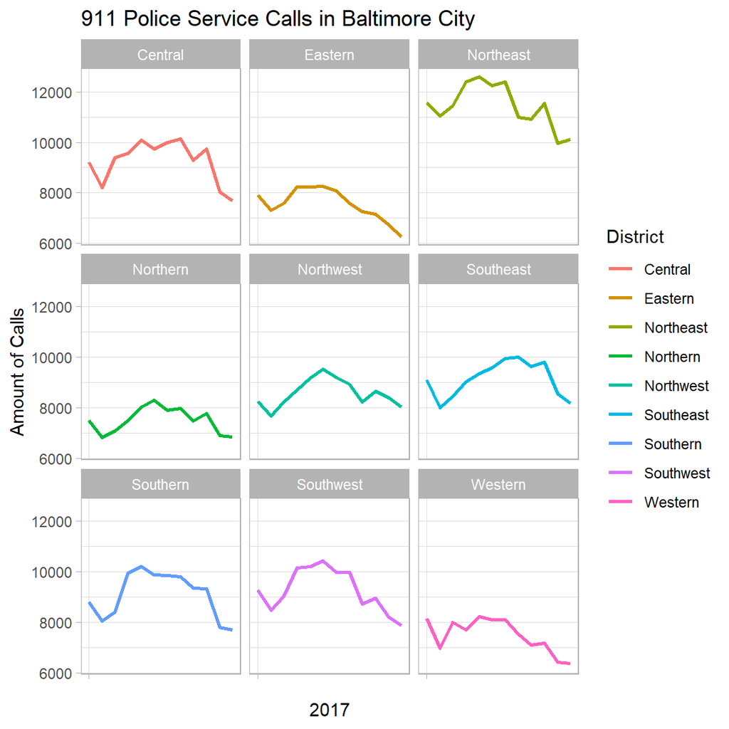

```r
ggplot(data = grouped.month,
       aes(x = month, y = count,
           color = District)) +
  scale_x_discrete(name = "2017",
                   limits = c(" ", " ", " ", " ", " ", " ",
                              " ", " ", " ",
                              " ", " ", " ")) +
  geom_line(size = 1) +
  xlab("2017") +
  ylab("Amount of Calls") +
  ggtitle("911 Police Service Calls in Baltimore City") +
  theme_light() +
  facet_wrap(~ District)
```

The districts follow a common trend in the amount of calls. From January to June there is a general positive slope, and from July to December there is a negative slope.

To graph my call priority data frame I did not have to do any major changes to my original data frame, besides renaming the districts.

## Priority Call Distribution Graph

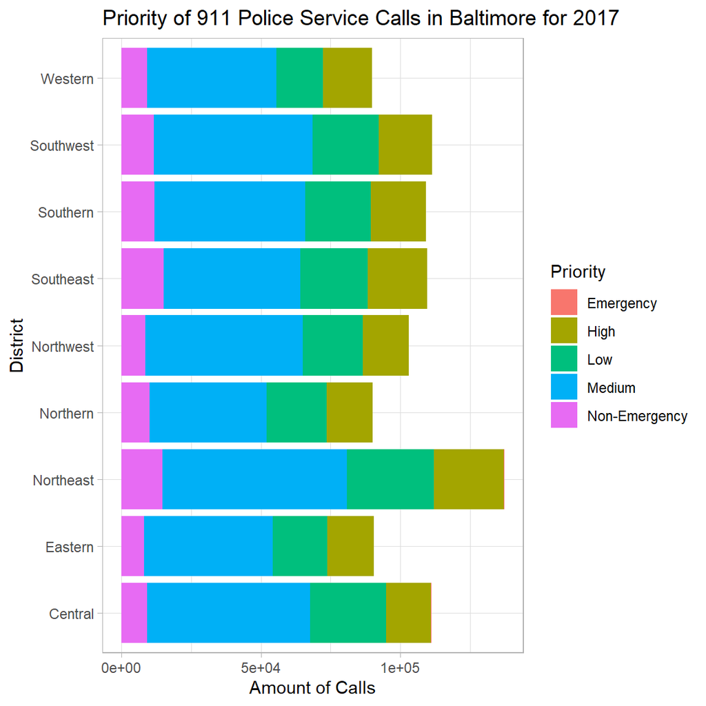

```r
ggplot(data=fix.graph.priority,
       aes(x= District, y=prioritycounts, fill=Priority)) +
  geom_bar(stat="identity")+
  xlab("District") +
  ylab("Amount of Calls") +
  ggtitle("Priority of 911 Police Service Calls in Baltimore for 2017") +
  theme_light() +
  coord_flip()
```

The priority call trend is similar across all districts, with a call with “Medium” priority being the most common and “Emergency” calls being the rarest.

# Conclusions

## Improvements

If someone were to work on this project with me I would explain all my subsets, because there are a lot of data frames in this script and it can be easy to get lost. While the final products look and are clean, I would improve upon the efficiency of my process to make it shorter. With this data set there are a lot of possibilities, for example you can analyze the difference in amount of calls per district in accordance to their impact in the redlining of Baltimore or the district demographics. Another interesting analysis with this data set could be call description, which I did not use. A great idea would be finding the relationship between call priority and call description and exploring the trends by district.